# From zero to hero: raw data to mapped networks - 3 Clustering

##### Check out the [user manual](https://creativedatasolutions.github.io/dave.docs/partial/cluster.html) for more details about this module’s features.

## Hierarchical clustering

##### Use the cluster >> hierarchical module to overview an unsupervised grouping of the data.

### Methods

##### Specify the node properties and what dimensions of the data (samples (rows), variables (columns) or both) to cluster. For example, the selected options will cluster both rows and columns, scale the data based on subtraction of column means and division of column standard deviations, annotate the heat map to show `class` and `age` for samples and fold-change of means for `class` and significantly altered variables.

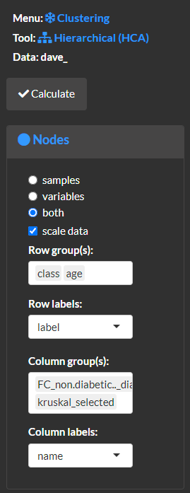

##### Use the method menu to specify if the raw data or correlations should be clustered, the distance and agglomeration method and how many groups should be extracted.

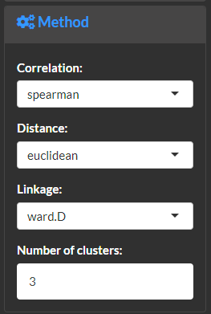

##### Select `calculate` and view the cluster analysis methods and results.

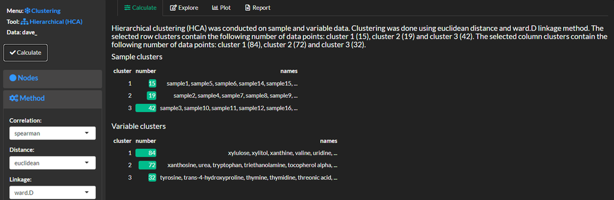

### Explore and plot

##### Create a `heatmap` or `dendrogram` to view the clustering results. Note, dendrograms are plotted separately for samples and/or columns.

##### Heatmap displaying hierarchical clusters for samples and/or variables.

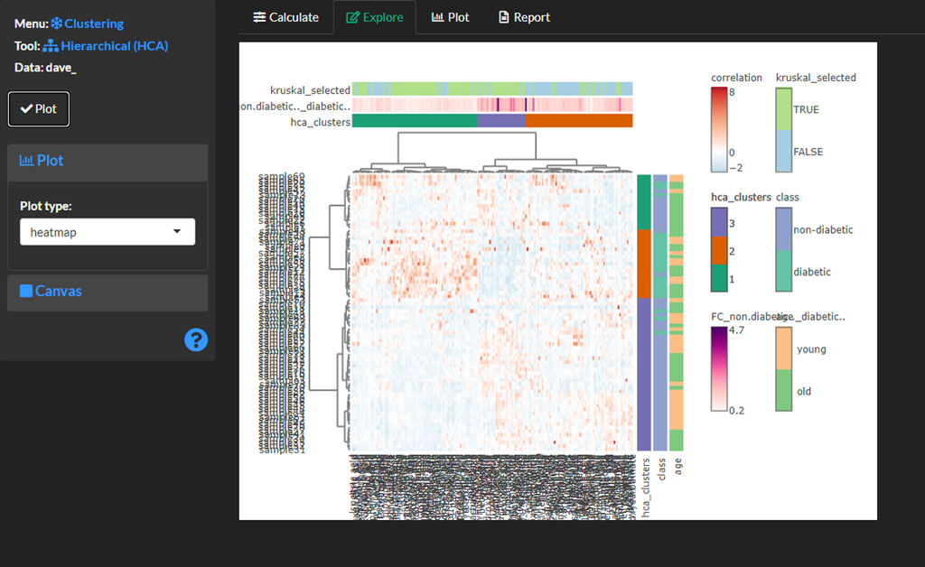

##### Dendrogram displaying hierarchical clusters for samples.

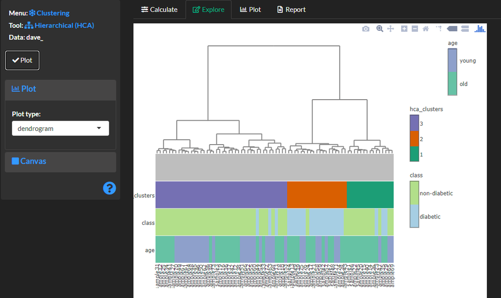

##### Dendrogram displaying hierarchical clusters for variables.

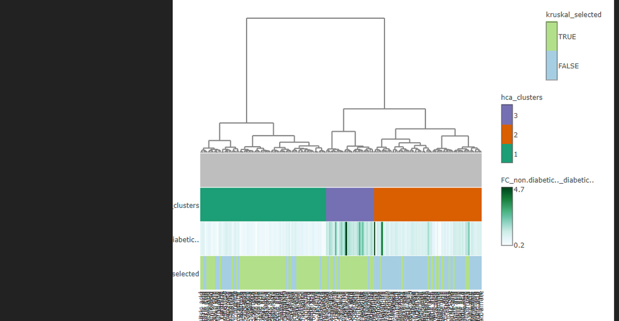

##### Create a report capturing the methods results and figures. Note, before creating the report use the plot menu to render the plots which were explored.

### Report

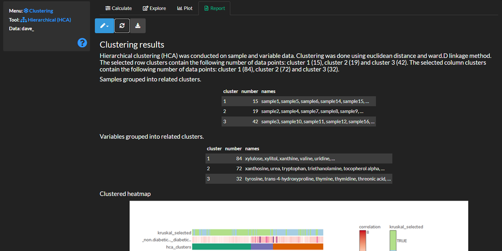

### Save

##### Next save the clustering results.